# Introduction to Solving Biological Problems Using R - Day 2

Mark Dunning, Suraj Menon and Aiora Zabala. Original material by Robert Stojnić, Laurent Gatto, Rob Foy, John Davey, Dávid Molnár and Ian Roberts

Last modified: 05 Jun 2017

# 2. Statistics

## Built-in support for statistics

- R is a statistical programming language:
  - Classical statistical tests are built-in
  - Statistical modeling functions are built-in
  - Regression analysis is fully supported
  - Additional mathematical packages are available (`MASS`, Waves, sparse matrices, etc)

## Distribution functions

- Most commonly used distributions are built-in, functions have stereotypical names, e.g. for normal distribution:
  - **`pnorm`** - cumulative distribution for x
  - **`qnorm`** - inverse of pnorm (from probability gives x)
  - **`dnorm`** - distribution density
  - **`rnorm`** - random number from normal distribution

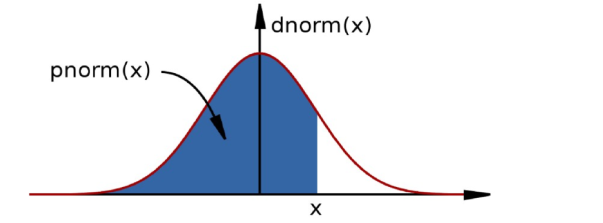

distributions

- Available for variety of distributions: `punif` (uniform), `pbinom` (binomial), `pnbinom` (negative binomial), `ppois` (poisson), `pgeom` (geometric), `phyper` (hyper-geometric), `pt` (T distribution), pf (F distribution)
- 10 random values from the Normal distribution with mean 10 and standard deviation 5:

```r
rnorm(10, mean=10, sd=5)
```

```
 [1] 21.949160  3.793762  5.177901 12.112667  7.872573 14.703928  2.960795 14.502868 13.856543  9.245594
```

- The probability of drawing exactly 10 from this distribution:

```r
dnorm(10, mean=10, sd=5)
```

```
[1] 0.07978846
```

```r
dnorm(100, mean=10, sd=5)
```

```
[1] 3.517499e-72
```

- The probability of drawing a value smaller than 10:

```r
pnorm(10, mean=10, sd=5)
```

```
[1] 0.5
```

- The inverse of `pnorm()`:

```r
qnorm(0.5, mean=10, sd=5)
```

```
[1] 10
```

- How many standard deviations for statistical significance?

```r
qnorm(0.95, mean=0, sd=1)
```

```
[1] 1.644854
```

## Example

Recall our histogram of Wind Speed from yesterday:

- The data look to be roughly normally-distributed
- An assumption we rely on for various statistical tests

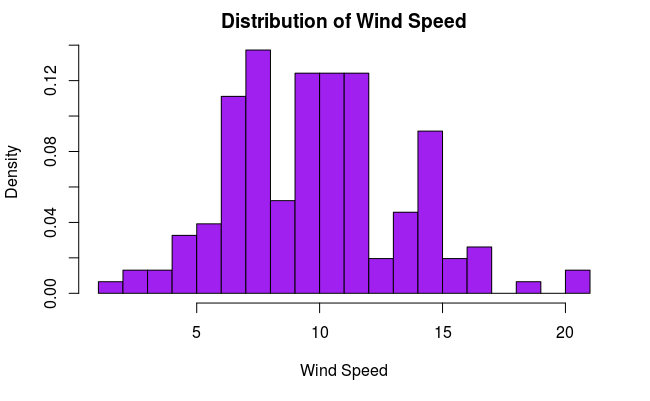

```r
weather <- read.csv("ozone.csv")
hist(weather$Wind, col="purple", xlab="Wind Speed",
     main="Distribution of Wind Speed",
     breaks = 20, freq=FALSE)
```

## Create a normal distribution curve

- If our data are normally-distributed, we can calculate the probability of drawing particular values.
  - e.g. a Wind Speed of 10

```r
windMean <- mean(weather$Wind)
windSD <- sd(weather$Wind)
dnorm(10, mean=windMean, sd=windSD)
```

```
[1] 0.1132311
```

- We can overlay this on the histogram using `points` as we just saw:

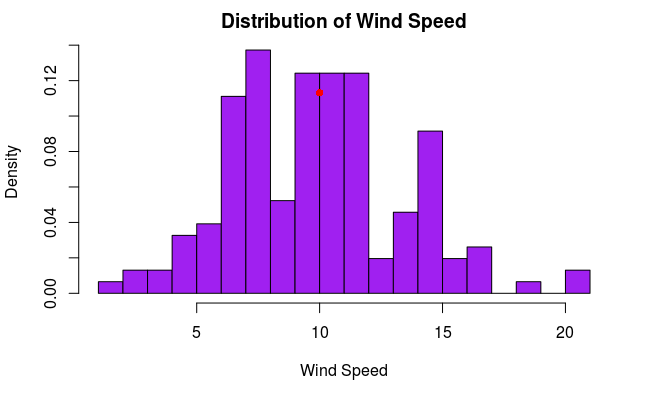

```r
hist(weather$Wind, col="purple", xlab="Wind Speed",
     main="Distribution of Wind Speed",
     breaks = 20, freq=FALSE)
points(10, dnorm(10, mean=windMean, sd=windSD),
       col="red", pch=16)
```

- We can repeat the calculation for a vector of values
  - remember that functions in R are often *vectorized*
  - use `lines` in this case rather than `points`

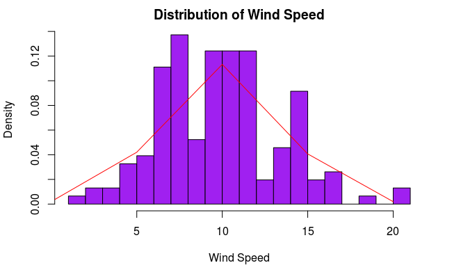

```r
xs <- c(0,5,10,15,20)
ys <- dnorm(xs, mean=windMean, sd=windSD)
hist(weather$Wind, col="purple", xlab="Wind Speed",
     main="Distribution of Wind Speed",
     breaks = 20, freq=FALSE)
lines(xs, ys, col="red")
```

- For a smoother curve, use a longer vector:
  - we can generate x values using the `seq()` function
- Inspecting the data in this manner is usually acceptable to assess normality
  - the fit doesn’t have to be exact
  - the shapiro test is also available `?shapiro.test` (but not really recommended by statisticians)

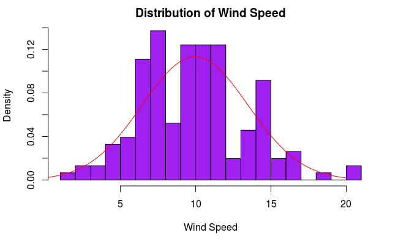

```r
hist(weather$Wind,col="purple",xlab="Wind Speed",
     main="Distribution of Wind Speed",breaks = 20,freq=FALSE)
xs <- seq(0,20, length.out = 10000)
ys <- dnorm(xs, mean=windMean,sd=windSD)
lines(xs,ys,col="red")
```